# Genetic Dependency Detection

Martin Brand

März 22, 2023

We import the libraries.

```r
library(tidyverse)
library(ggplot2)
library(ggrepel)
library(matrixTests)
library(dplyr)
library(cowplot)
library(limma)
library(gridExtra)
```

# Analyzed Genes and Target

We define the genes for classification, the expected target gene and the classification criteria.

```r
gene1 <- "FUBP1"
gene2 <- "PCBP1"
target.genes <- c("FUBP1","SF1","U2AF1","U2AF2","SNRPB","SNRPD1","SNRPD2",
                  "SNRPD3","SNRPE","SNRPF","SNRPG","PUF60","SMNDC1",
                  "DNAJC8","RBM17","CHERP","U2SURP","DHX15","DDX46","CELF6",
                  "PCBP1")
# possible methods: "del.vs.non.del", "del.vs.non.mut","mut.vs.non.mut"
classification.method <- "mut.vs.non.mut"
```

In this analysis, the genes used for classification are FUBP1 and PCBP1. The expected target gene is FUBP1, SF1, U2AF1, U2AF2, SNRPB, SNRPD1, SNRPD2, SNRPD3, SNRPE, SNRPF, SNRPG, PUF60, SMNDC1, DNAJC8, RBM17, CHERP, U2SURP, DHX15, DDX46, CELF6, PCBP1.

# Data Preprocessing

We define the directory for the data and helper functions.

```r
data.dir <-
  "C:/Users/Martin/Documents/Master/Thesis/genetic_dependency_detection/data/"
```

We load the dataset that contains CCLE IDs and corresponding DepMap IDs for the cell lines ([DepMapIDs](https://depmap.org/portal/download/all/?releasename=DepMap+Public+18Q3&filename=DepMap-2018q3-celllines.csv)), the dataset that contains the mutation information of the cell lines ([CCLE dataset](https://depmap.org/portal/download/all/?releasename=DepMap+Public+19Q2&filename=CCLE_mutations.csv)) and the datasets that contains the dependency scores from the projects Achilles and DRIVE ([DepMap datasets](https://figshare.com/articles/dataset/DepMap_Datasets_for_WRN_manuscript/7712756/1)).

```r
cancer.names <- read.csv(paste0(data.dir, "DepMap-2018q3-celllines.csv"))
cancer.names <- cancer.names[,c(1,2)]
colnames(cancer.names) <- c("DepMap_ID","CCLE_ID")

CCLE.mut <- read.csv(paste0(data.dir, "CCLE_mutations.csv"))
CCLE.mut <- CCLE.mut[,c(1,8,16,20)]

dep.scores <- read_rds(file.path(data.dir, 'DepMap_18Q4_data.rds'))

dep.scores.DRIVE <- as.data.frame(dep.scores[["DRIVE"]])
dep.scores.DRIVE$CCLE_ID <- rownames(dep.scores.DRIVE)
rownames(dep.scores.DRIVE) <- NULL
dep.scores.DRIVE <- dep.scores.DRIVE %>% select(CCLE_ID, everything())

dep.scores.Achilles <- as.data.frame(dep.scores[["CRISPR"]])
dep.scores.Achilles$CCLE_ID <- rownames(dep.scores.Achilles)
rownames(dep.scores.Achilles) <- NULL
dep.scores.Achilles <- dep.scores.Achilles %>% select(CCLE_ID,everything())

# remove unnecessary objects
rm(dep.scores)

# save important objects
saveRDS(cancer.names,paste0(data.dir,"cancer.names.rds"))
saveRDS(CCLE.mut,paste0(data.dir,"CCLE.mut.rds"))
saveRDS(dep.scores.DRIVE,paste0(data.dir,"dep.scores.DRIVE.rds"))
saveRDS(dep.scores.Achilles,paste0(data.dir,"dep.scores.Achilles.rds"))
```

```r
# load important objects
cancer.names <- readRDS(paste0(data.dir,"cancer.names.rds"))
CCLE.mut <- readRDS(paste0(data.dir,"CCLE.mut.rds"))
dep.scores.DRIVE <- readRDS(paste0(data.dir,"dep.scores.DRIVE.rds"))
dep.scores.Achilles <- readRDS(paste0(data.dir,"dep.scores.Achilles.rds"))
```

We load the helper functions.

```r
# load helper functions
source("helper_functions/create.mutation.counts.plot.R")
source("helper_functions/create.mutation.counts.plot.mark.R")
source("helper_functions/create.classification.table.del.vs.non.del.R")
source("helper_functions/create.classification.table.mut.vs.non.mut.R")
source("helper_functions/create.classification.table.del.vs.non.mut.R")
source("helper_functions/merge.class.tables.R")
source("helper_functions/create_barcharts_classifications.R")
source("helper_functions/plot.mean.diffs.R")
source("helper_functions/calc.mean.diffs.and.p.values.R")
source("helper_functions/create_volcano_plot.R")
source("helper_functions/create.significant.genes.table.R")
```

# Data Exploration

## Mutation Counts

To find potential genes for classification, we plot the distribution of mutation numbers in the overlapping genes of the CCLE dataset and the datasets DRIVE and Achilles.

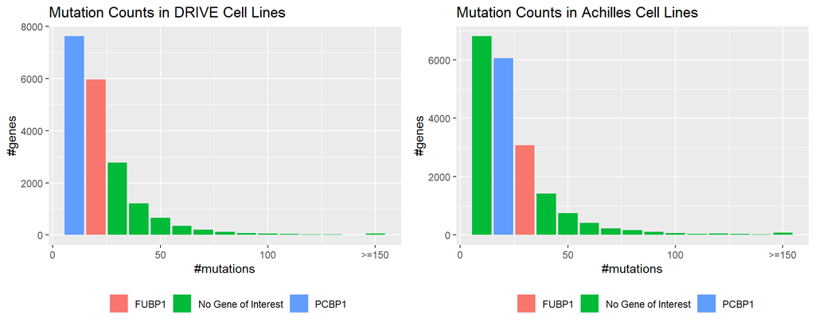

```r
mutation.plot.DRIVE <- create.mutation.counts.plot.mark("DRIVE",dep.scores.DRIVE,
                                                   cancer.names,CCLE.mut)

mutation.plot.Achilles <- create.mutation.counts.plot.mark("Achilles",
                                                      dep.scores.Achilles,
                                                      cancer.names,CCLE.mut)

grid.arrange(mutation.plot.DRIVE,mutation.plot.Achilles,ncol=2)
```

```r
rm(mutation.plot.DRIVE,mutation.plot.Achilles)
```

## Classification Tables for FUBP1 and PCBP1

We create classification tables that show us for each cell line whether the selected genes are deleteriously mutated or not. Therefore we create one table where we check whether FUBP1 is deleteriously mutated, another table where we do the same for PCBP1 and a third table where we check whether at least one of FUBP1 and PCBP1 is deleteriously mutated.

```r
create.classification.table <- switch(classification.method,
                "del.vs.non.del" = create.classification.table.del.vs.non.del,
                "del.vs.non.mut" = create.classification.table.del.vs.non.mut,
                "mut.vs.non.mut" = create.classification.table.mut.vs.non.mut)

class.table.gene1 <- create.classification.table(
                                                CCLE.mut, cancer.names,
                                                gene1, dep.scores.DRIVE,
                                                dep.scores.Achilles)
class.table.gene2 <- create.classification.table(
                                                CCLE.mut, cancer.names,
                                                gene2, dep.scores.DRIVE,
                                                dep.scores.Achilles)

# merge tables
class.table.comb.DRIVE <- merge.class.tables(class.table.gene1$DRIVE,
                                             class.table.gene2$DRIVE)

class.table.comb.Achilles <- merge.class.tables(class.table.gene1$Achilles,
                                             class.table.gene2$Achilles)

head(class.table.comb.DRIVE)
```

```
##                                  CCLE_ID isDeleterious
## 1                     127399_SOFT_TISSUE         FALSE
## 2          1321N1_CENTRAL_NERVOUS_SYSTEM         FALSE
## 3                        2313287_STOMACH         FALSE
## 4 697_HAEMATOPOIETIC_AND_LYMPHOID_TISSUE         FALSE
## 5                            769P_KIDNEY         FALSE
## 6                            786O_KIDNEY         FALSE
```

```r
rm(CCLE.mut,cancer.names)
```

## Classifications for FUBP1

To check whether the samples sizes regarding FUBP1 for the following statistical tests are sufficient, we plot the number of cell lines for both samples.

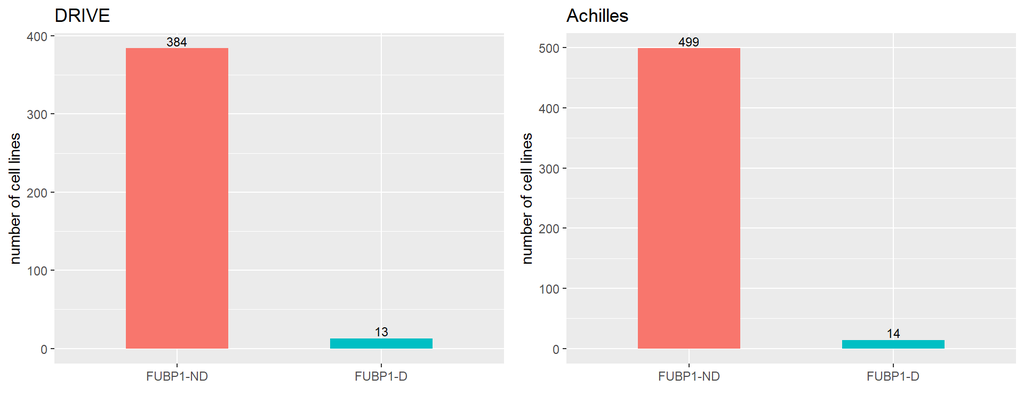

```r
barcharts.gene1 <- create_barcharts_classifications(class.table.gene1$DRIVE,
                                              class.table.gene1$Achilles,
                                              gene1)
plot_grid(barcharts.gene1$DRIVE, barcharts.gene1$Achilles)
```

```r
rm(barcharts.gene1)
```

## Classifications for PCBP1

We repeat the plots for PCBP1.

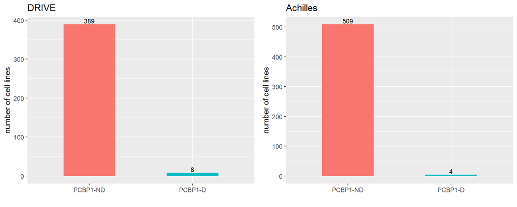

```r
barcharts.gene2 <- create_barcharts_classifications(class.table.gene2$DRIVE,
                                              class.table.gene2$Achilles,
                                              gene2)
plot_grid(barcharts.gene2$DRIVE, barcharts.gene2$Achilles)
```

```r
rm(barcharts.gene2)
```

## Classifications for FUBP1and PCBP1

We repeat the plots for FUBP1and PCBP1.

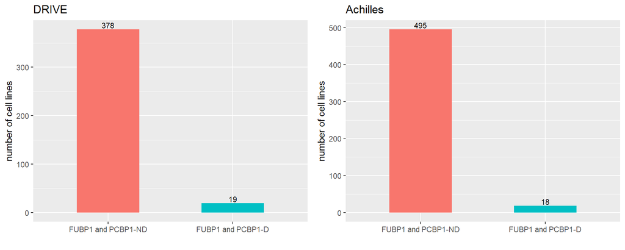

```r
barcharts.comb.genes <- create_barcharts_classifications(class.table.comb.DRIVE,
                                              class.table.comb.Achilles,
                                              paste(gene1,"and",gene2))
plot_grid(barcharts.comb.genes$DRIVE, barcharts.comb.genes$Achilles)
```

```r
rm(barcharts.comb.genes)
```

# Data Analysis FUBP1

In order to detect differences between both samples, we compare them for each gene in the datasets DRIVE and Achilles. The workflow was published by [Chan et al., 2019](https://www.nature.com/articles/s41586-019-1102-x).

## Mean Differences

To test whether the two groups respond differently to the knock out or the knock down of a specific gene, we calculate the mean differences between the two groups for each gene.

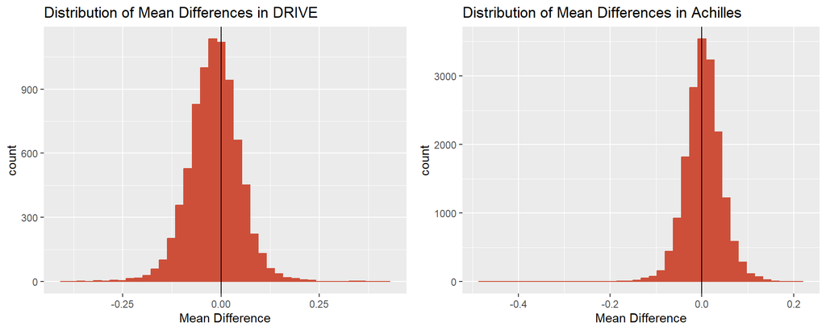

```r
test.results.gene1 <- calc.mean.diffs.and.p.values(dep.scores.DRIVE,
                                           dep.scores.Achilles,
                                           class.table.gene1$DRIVE,
                                           class.table.gene1$Achilles)

plots <- plot.mean.diffs(test.results.gene1)
grid.arrange(plots$DRIVE,plots$Achilles,ncol=2)
```

```r
rm(class.table.gene1,plots)
```

## Welch Test

The Welch t-test checks whether the means of two samples are identical. The prerequisite is that both samples are normally distributed, which we have not yet ensured.

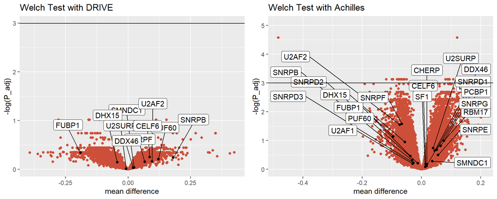

```r
plot.welch.DRIVE.gene1 <- create_volcano_plot(test.results.gene1,"DRIVE",
                                              "welch",target.genes,
                                              show_sign_line=T)

plot.welch.Achilles.gene1 <- create_volcano_plot(test.results.gene1,"Achilles",
                                                "welch",target.genes)

grid.arrange(plot.welch.DRIVE.gene1,plot.welch.Achilles.gene1,ncol=2)
```

```r
rm(plot.welch.DRIVE.gene1,plot.welch.Achilles.gene1)
```

To discover new potential dependencies, the table shows all significant genes.

```r
significant.genes.table.DRIVE.gene1 <- create.significant.genes.table(
  test.results.gene1,"DRIVE","welch")
significant.genes.table.Achilles.gene1 <- create.significant.genes.table(
  test.results.gene1,"Achilles","welch")
significant.genes.table.DRIVE.gene1
```

```
## [1] gene    p_value p_adj   log
## <0 rows> (or 0-length row.names)
```

```r
significant.genes.table.Achilles.gene1
```

```
##           gene      p_value      p_adj      log
## 1473      BRAF 7.352886e-07 0.01035925 4.569875
## 14997   TBC1D3 1.174918e-06 0.01035925 4.569875
## 490   ALDH18A1 4.294199e-05 0.04382830 3.127476
## 1176  ATP6V1G3 8.269525e-06 0.04382830 3.127476
## 1719  C17orf82 5.181635e-05 0.04382830 3.127476
## 1964   C5orf46 4.690187e-05 0.04382830 3.127476
## 2498     CCNG2 5.508107e-05 0.04382830 3.127476
## 3849     DCDC1 3.552652e-05 0.04382830 3.127476
## 4388      DVL1 2.630782e-05 0.04382830 3.127476
## 5050   FAM181B 4.908521e-05 0.04382830 3.127476
## 6167     GPR18 1.904889e-05 0.04382830 3.127476
## 9877    NKX3-2 4.379837e-05 0.04382830 3.127476
## 9973      NOTO 5.534556e-05 0.04382830 3.127476
## 10983   PCED1B 4.394199e-05 0.04382830 3.127476
## 11512      PML 4.963901e-05 0.04382830 3.127476
## 13030     RPSA 1.133794e-05 0.04382830 3.127476
## 13596   SH3RF2 3.117560e-05 0.04382830 3.127476
## 14706    STRN3 1.461123e-05 0.04382830 3.127476
## 14725     STX7 5.169381e-05 0.04382830 3.127476
## 14944  TAS2R10 3.884574e-05 0.04382830 3.127476
## 16941   ZBTB44 5.716519e-05 0.04382830 3.127476
## 17054  ZFYVE19 1.638854e-05 0.04382830 3.127476
## 17477   ZNF707 2.311217e-05 0.04382830 3.127476
```

```r
rm(significant.genes.table.DRIVE.gene1,significant.genes.table.Achilles.gene1)
```

## Wilcoxon Test

The Wilcoxon test checks whether, for randomly selected values X and Y from two samples, the probability of X being greater than Y is equal to the probability of Y being greater than X. The prerequisite is that the data are ordinary, which is fulfilled here.

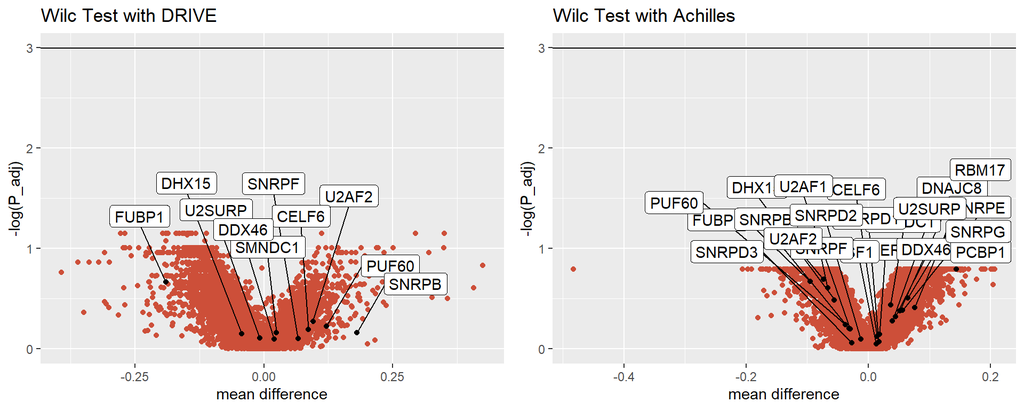

```r
plot.wilc.DRIVE.gene1 <- create_volcano_plot(test.results.gene1,"DRIVE","wilc",
                                       target.genes, show_sign_line=T)

plot.wilc.Achilles.gene1 <- create_volcano_plot(test.results.gene1,"Achilles",
                                                "wilc",target.genes)

grid.arrange(plot.wilc.DRIVE.gene1,plot.wilc.Achilles.gene1,ncol=2)
```

```r
rm(plot.wilc.DRIVE.gene1,plot.wilc.Achilles.gene1)
```

```r
significant.genes.table.DRIVE.gene1 <- create.significant.genes.table(
  test.results.gene1,"DRIVE","wilc")
significant.genes.table.Achilles.gene1 <- create.significant.genes.table(
  test.results.gene1,"Achilles","wilc")
significant.genes.table.DRIVE.gene1
```

```
## [1] gene    p_value p_adj   log
## <0 rows> (or 0-length row.names)
```

```r
significant.genes.table.Achilles.gene1
```

```
## [1] gene    p_value p_adj   log
## <0 rows> (or 0-length row.names)
```

```r
rm(significant.genes.table.DRIVE.gene1,significant.genes.table.Achilles.gene1)
```

## Bayes Test

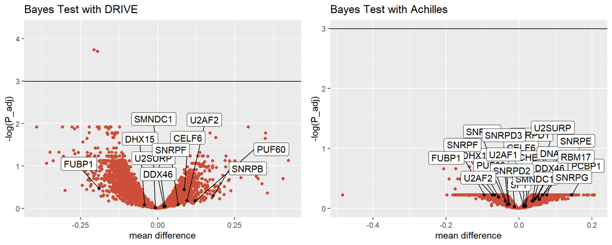

```r
plot.bayes.DRIVE.gene1 <- create_volcano_plot(test.results.gene1,"DRIVE","bayes",
                                       target.genes)

plot.bayes.Achilles.gene1 <- create_volcano_plot(test.results.gene1,"Achilles",
                                                "bayes",target.genes)

grid.arrange(plot.bayes.DRIVE.gene1,plot.bayes.Achilles.gene1,ncol=2)
```

```r
rm(plot.bayes.DRIVE.gene1,plot.bayes.Achilles.gene1)
```

```r
significant.genes.table.DRIVE.gene1 <- create.significant.genes.table(
  test.results.gene1,"DRIVE","bayes")
significant.genes.table.Achilles.gene1 <- create.significant.genes.table(
  test.results.gene1,"Achilles","bayes")
significant.genes.table.DRIVE.gene1
```

```
##        gene      p_adj      log
## 1691 EHHADH 0.02387656 3.734858
## 3119    HK1 0.02475680 3.698655
```

```r
significant.genes.table.Achilles.gene1
```

```
## [1] gene  p_adj log
## <0 rows> (or 0-length row.names)
```

```r
rm(significant.genes.table.DRIVE.gene1,significant.genes.table.Achilles.gene1,
   test.results.gene1)
```

# Data Analysis PCBP1

We do the same for PCBP1.

## Mean Differences

```r
test.results.gene2 <- calc.mean.diffs.and.p.values(dep.scores.DRIVE,
                                           dep.scores.Achilles,
                                           class.table.gene2$DRIVE,
                                           class.table.gene2$Achilles)
```

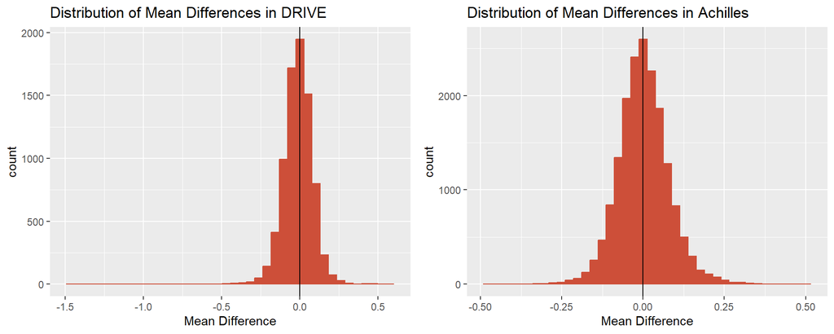

```r
plots <- plot.mean.diffs(test.results.gene2)
grid.arrange(plots$DRIVE,plots$Achilles,ncol=2)
```

```r
rm(class.table.gene2,plots)
```

## Welch Test

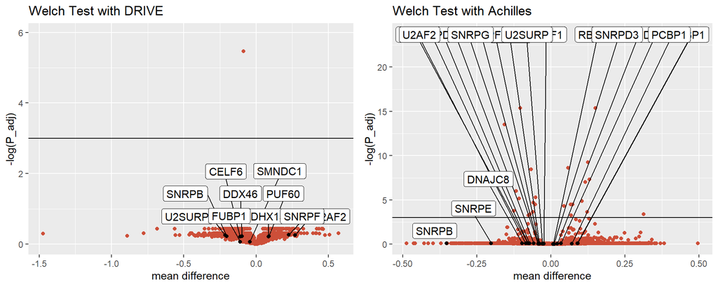

```r
plot.welch.DRIVE.gene2 <- create_volcano_plot(test.results.gene2,"DRIVE",
                                              "welch",target.genes,
                                              show_sign_line=T)

plot.welch.Achilles.gene2 <- create_volcano_plot(test.results.gene2,"Achilles",
                                                "welch",target.genes)

grid.arrange(plot.welch.DRIVE.gene2,plot.welch.Achilles.gene2,ncol=2)
```

```r
rm(plot.welch.DRIVE.gene2,plot.welch.Achilles.gene2)
```

```r
significant.genes.table.DRIVE.gene2 <- create.significant.genes.table(
  test.results.gene2,"DRIVE","welch")
significant.genes.table.Achilles.gene2 <- create.significant.genes.table(
  test.results.gene2,"Achilles","welch")
significant.genes.table.DRIVE.gene2
```

```
##        gene      p_value       p_adj      log
## 5738 DMRTA1 5.308999e-07 0.004233396 5.464751
```

```r
significant.genes.table.Achilles.gene2
```

```
##           gene      p_value        p_adj       log
## 3543     CSHL1 4.411514e-15 7.779263e-11 23.276974
## 10049    NR2C2 2.614369e-11 2.095306e-07 15.378396
## 10743     OTX2 3.564658e-11 2.095306e-07 15.378396
## 5897     GIPC2 2.997555e-10 1.321472e-06 13.536764
## 9319      MT1X 2.664845e-08 9.398375e-05  9.272389
## 16746     WEE2 6.072501e-08 1.784708e-04  8.631086
## 1384     BFSP2 8.472200e-08 2.134268e-04  8.452217
## 2795     CENPB 3.036390e-07 6.692962e-04  7.309284
## 7371      ITPA 4.671118e-07 9.152277e-04  6.996338
## 8318     LPAR5 1.391089e-06 2.453047e-03  6.010424
## 5715    GALNT3 3.209537e-06 5.145179e-03  5.269695
## 5998     GNA15 3.950681e-06 5.805526e-03  5.148945
## 1797  C1orf131 5.656198e-06 7.672415e-03  4.870124
## 6876    HSPA1B 7.162195e-06 9.021296e-03  4.708167
## 6293      GSC2 1.066543e-05 1.106318e-02  4.504132
## 12031     PSD3 1.005031e-05 1.106318e-02  4.504132
## 12542     RBP7 9.898467e-06 1.106318e-02  4.504132
## 11881    PRKCD 1.369336e-05 1.341493e-02  4.311387
## 14865    SYVN1 2.490250e-05 2.311214e-02  3.767397
## 12299    RAB20 3.178695e-05 2.669196e-02  3.623393
## 12487    RBBP8 3.108866e-05 2.669196e-02  3.623393
## 10037    NPY5R 4.162648e-05 3.336552e-02  3.400232
## 16724    WDR73 4.486761e-05 3.439980e-02  3.369704
## 10423    OR2G2 5.479207e-05 3.864813e-02  3.253257
## 12015   PRSS55 5.401030e-05 3.864813e-02  3.253257
```

```r
rm(significant.genes.table.DRIVE.gene2,significant.genes.table.Achilles.gene2)
```

## Wilcoxon Test

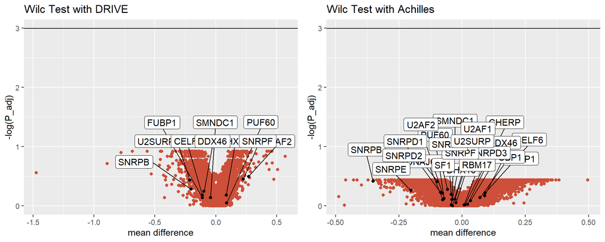

```r
plot.wilc.DRIVE.gene2 <- create_volcano_plot(test.results.gene2,"DRIVE","wilc",
                                       target.genes, show_sign_line=T)

plot.wilc.Achilles.gene2 <- create_volcano_plot(test.results.gene2,"Achilles",
                                                "wilc",target.genes)

grid.arrange(plot.wilc.DRIVE.gene2,plot.wilc.Achilles.gene2,ncol=2)
```

```r
rm(plot.wilc.DRIVE.gene2,plot.wilc.Achilles.gene2)
```

```r
significant.genes.table.DRIVE.gene2 <- create.significant.genes.table(
  test.results.gene2,"DRIVE","wilc")
significant.genes.table.Achilles.gene2 <- create.significant.genes.table(
  test.results.gene2,"Achilles","wilc")
significant.genes.table.DRIVE.gene2
```

```
## [1] gene    p_value p_adj   log
## <0 rows> (or 0-length row.names)
```

```r
significant.genes.table.Achilles.gene2
```

```
## [1] gene    p_value p_adj   log
## <0 rows> (or 0-length row.names)
```

```r
rm(significant.genes.table.DRIVE.gene2,significant.genes.table.Achilles.gene2)
```

## Bayes Test

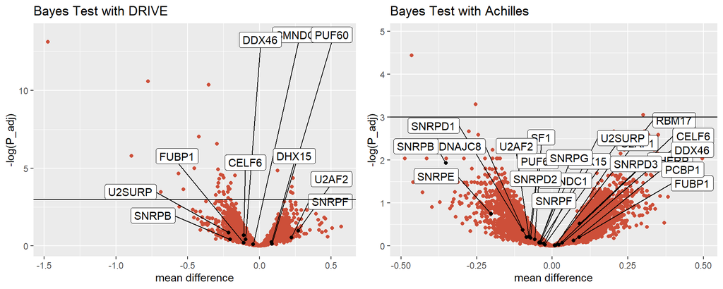

```r
plot.bayes.DRIVE.gene2 <- create_volcano_plot(test.results.gene2,"DRIVE","bayes",
                                       target.genes)

plot.bayes.Achilles.gene2 <- create_volcano_plot(test.results.gene2,"Achilles",
                                                "bayes",target.genes)

grid.arrange(plot.bayes.DRIVE.gene2,plot.bayes.Achilles.gene2,ncol=2)
```

```r
rm(plot.bayes.DRIVE.gene2,plot.bayes.Achilles.gene2)
```

```r
significant.genes.table.DRIVE.gene2 <- create.significant.genes.table(
  test.results.gene2,"DRIVE","bayes")
significant.genes.table.Achilles.gene2 <- create.significant.genes.table(
  test.results.gene2,"Achilles","bayes")
significant.genes.table.DRIVE.gene2
```

```
##             gene        p_adj       log
## 1356      CTNNB1 1.958571e-06 13.143296
## 6473         WRN 2.493203e-05 10.599357
## 1626         AGT 3.096357e-05 10.382699
## 7438       CCND2 8.851156e-04  7.029792
## 5402       ZBTB2 1.403784e-03  6.568584
## 3899        MCL1 3.059487e-03  5.789508
## 6484       XRCC5 6.715754e-03  5.003299
## 6786      DNAJC5 7.237759e-03  4.928444
## 89   SEPT5-GP1BB 7.821468e-03  4.850883
## 1259     EIF5AL1 9.607593e-03  4.645202
## 3901        MCM3 1.017947e-02  4.587382
## 5504     RAB3IL1 1.084543e-02  4.524011
## 7497       TAAR5 1.084543e-02  4.524011
## 2194     PIP5K1C 1.240538e-02  4.389625
```

[output cut: 19 more lines]

```r
significant.genes.table.Achilles.gene2
```

```
##        gene      p_adj      log
## 13217 SATB2 0.01185181 4.435275
## 12606   REN 0.03702086 3.296274
## 14768 SUMO4 0.04723500 3.052620
```

```r
rm(significant.genes.table.DRIVE.gene2,significant.genes.table.Achilles.gene2,
   test.results.gene2)
```

# Data Analysis FUBP1 and PCBP1

We do the same for FUBP1 and PCBP1 combined.

## Mean Differences

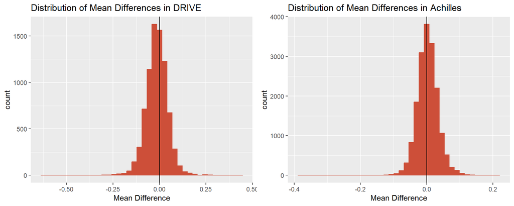

```r
test.results.gene12 <- calc.mean.diffs.and.p.values(dep.scores.DRIVE,
                                           dep.scores.Achilles,
                                           class.table.comb.DRIVE,
                                           class.table.comb.Achilles)

plots <- plot.mean.diffs(test.results.gene12)
grid.arrange(plots$DRIVE,plots$Achilles,ncol=2)
```

```r
rm(class.table.comb.DRIVE,class.table.comb.Achilles,plots)
```

## Welch Test

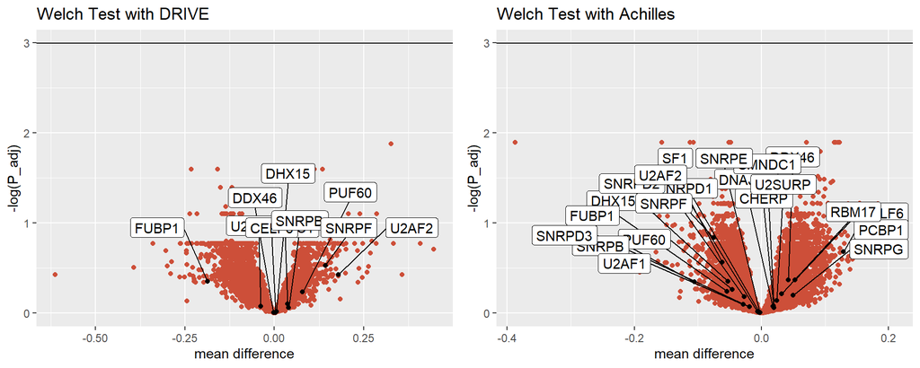

```r
plot.welch.DRIVE.gene12 <- create_volcano_plot(test.results.gene12,"DRIVE",
                                              "welch",target.genes)

plot.welch.Achilles.gene12 <- create_volcano_plot(test.results.gene12,"Achilles",
                                                "welch",target.genes)

grid.arrange(plot.welch.DRIVE.gene12,plot.welch.Achilles.gene12,ncol=2)
```

```r
rm(plot.welch.DRIVE.gene12,plot.welch.Achilles.gene12)
```

```r
significant.genes.table.DRIVE.gene12 <- create.significant.genes.table(
  test.results.gene12,"DRIVE","welch")
significant.genes.table.Achilles.gene12 <- create.significant.genes.table(
  test.results.gene12,"Achilles","welch")
significant.genes.table.DRIVE.gene12
```

```
## [1] gene    p_value p_adj   log
## <0 rows> (or 0-length row.names)
```

```r
significant.genes.table.Achilles.gene12
```

```
## [1] gene    p_value p_adj   log
## <0 rows> (or 0-length row.names)
```

```r
rm(significant.genes.table.DRIVE.gene12,significant.genes.table.Achilles.gene12)
```

## Wilcoxon Test

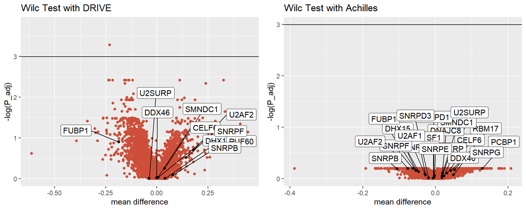

```r
plot.wilc.DRIVE.gene12 <- create_volcano_plot(test.results.gene12,"DRIVE","wilc",
                                       target.genes, show_sign_line=T)

plot.wilc.Achilles.gene12 <- create_volcano_plot(test.results.gene12,"Achilles",
                                                "wilc",target.genes)

grid.arrange(plot.wilc.DRIVE.gene12,plot.wilc.Achilles.gene12,ncol=2)
```

```r
rm(plot.wilc.DRIVE.gene12,plot.wilc.Achilles.gene12)
```

```r
significant.genes.table.DRIVE.gene12 <- create.significant.genes.table(
  test.results.gene12,"DRIVE","wilc")
significant.genes.table.Achilles.gene12 <- create.significant.genes.table(
  test.results.gene12,"Achilles","wilc")
significant.genes.table.DRIVE.gene12
```

```
##       gene      p_value      p_adj      log
## 5403 ZBTB2 4.723954e-06 0.03767353 3.278798
```

```r
significant.genes.table.Achilles.gene12
```

```
## [1] gene    p_value p_adj   log
## <0 rows> (or 0-length row.names)
```

```r
rm(significant.genes.table.DRIVE.gene12,significant.genes.table.Achilles.gene12)
```

## Bayes Test

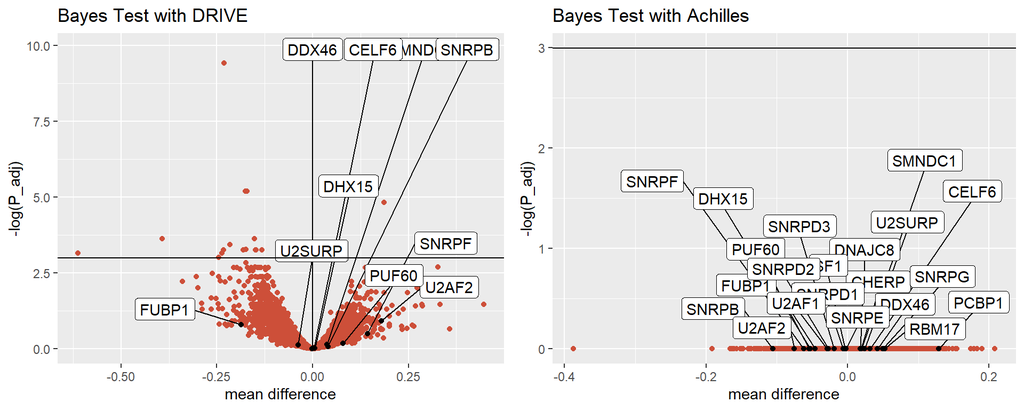

```r
plot.bayes.DRIVE.gene12 <- create_volcano_plot(test.results.gene12,"DRIVE",
                                               "bayes",target.genes)

plot.bayes.Achilles.gene12 <- create_volcano_plot(test.results.gene12,
                                                  "Achilles","bayes",
                                                  target.genes)

grid.arrange(plot.bayes.DRIVE.gene12,plot.bayes.Achilles.gene12,ncol=2)
```

```r
rm(plot.bayes.DRIVE.gene12,plot.bayes.Achilles.gene12)
```

```r
significant.genes.table.DRIVE.gene12 <- create.significant.genes.table(
  test.results.gene12,"DRIVE","bayes")
significant.genes.table.Achilles.gene12 <- create.significant.genes.table(
  test.results.gene12,"Achilles","bayes")
significant.genes.table.DRIVE.gene12
```

```
##                     gene        p_adj      log
## 5403               ZBTB2 0.0000816161 9.413484
## 1691              EHHADH 0.0055862547 5.187446
## 3119                 HK1 0.0055862547 5.187446
## 6575               DDX50 0.0080422322 4.823049
## 6474                 WRN 0.0264334254 3.633126
## 1433             ANKRD46 0.0265774994 3.627690
## 4383                VRK3 0.0324545420 3.427915
## 1627                 AGT 0.0374574725 3.284549
## 119           BIVM-ERCC5 0.0382925390 3.262500
## 499  TBC1D7-LOC100130357 0.0382925390 3.262500
## 3590               ARL4D 0.0382925390 3.262500
## 4397               CDK18 0.0382925390 3.262500
## 6427                USP1 0.0382925390 3.262500
## 1357              CTNNB1 0.0429919558 3.146742
## 7877              BCLAF1 0.0429919558 3.146742
## 4004            MAP1LC3C 0.0494615424 3.006560
```

```r
significant.genes.table.Achilles.gene12
```

```
## [1] gene  p_adj log
## <0 rows> (or 0-length row.names)
```

```r
rm(significant.genes.table.DRIVE.gene12,significant.genes.table.Achilles.gene12,
   test.results.gene12)
```